# Barbell Lifts Correctness Prediction

Xingmin Aaron Zhang

## Introduction

The goal of this study is to explore how to predict whether an individual performs barbell lifts correctly from wearable tracking devices.

## Load data

The data is generously provided by [Web.archive.org](http://web.archive.org/web/20161224072740/http:/groupware.les.inf.puc-rio.br/har). In this dataset, 6 participants performed barbell lifts correctly and incorrectly in 5 different ways: exactly according to the specification (Class A), throwing the elbows to the front (Class B), lifting the dumbbell only halfway (Class C), lowering the dumbbell only halfway (Class D) and throwing the hips to the front (Class E).

```r
trainingurl <- url("https://d396qusza40orc.cloudfront.net/predmachlearn/pml-training.csv")
testingurl <-url("https://d396qusza40orc.cloudfront.net/predmachlearn/pml-testing.csv")

training <- read.csv(trainingurl)
testing <- read.csv(testingurl)
```

## Exploratory analysis

```r
library(tidyverse)
missingCount <- sapply(training, function(x) { sum(is.na(x) | x == "")})
s <- split(missingCount, as.factor(missingCount))
d <- lapply(s, length)
d
```

```
## $`0`
## [1] 60
##
## $`19216`
## [1] 100
```

We can see that 60 variables have no missing values, while the rest 100 variables, which are summary data, have a lot missing values. We use this fact to extract raw data for building predictive models.

```r
rawVars <- names(missingCount[missingCount== 0])
rawVars <- rawVars[-seq(1, 7)]

training_raw <- training %>% select(c(rawVars, "classe"))
testing_raw <- testing %>% select(rawVars[-length(rawVars)])
```

## Building Prediction Models

We partition the training data into two subsets, one for actual training and the other for testing the models. In the final step, we will use the models to predict the unknown cases in testing sets.

```r
library(caret)
require(doSNOW)
train_index <- createDataPartition(training_raw$classe, p = 0.7, list = FALSE)
train_raw_train <- training_raw[train_index, ]
train_raw_test <- training_raw[-train_index, ]
```

There are a lot of independent variables in this dataset. We probably do not need all of them, so we performed a simple random forest to identify important features. Based on the importance, we selected the first 36 varialbes in the figure below.

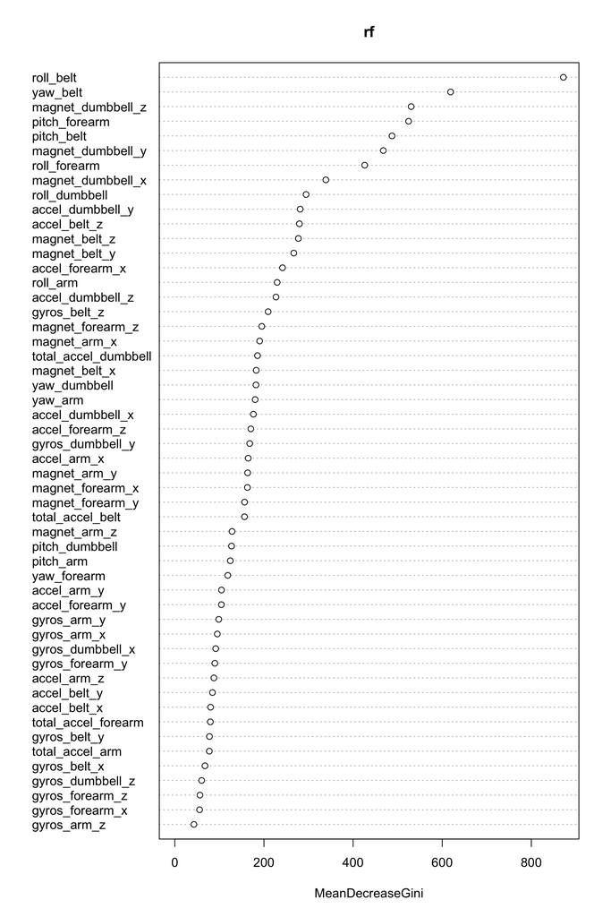

Figure 1. feature importance

```r
library(randomForest)
rf <- randomForest(classe ~ ., data = train_raw_train)
featureImportance <- rf$importance
names(featureImportance) <- row.names(featureImportance)
featureImportance <- sort(featureImportance, decreasing = TRUE)
varImpPlot(rf, type = 2, n.var = 52)
```

```r
featureSelect <- names(featureImportance[1:36])
train_raw_train <- train_raw_train[,c(featureSelect, "classe")]
train_raw_test <- train_raw_test[,c(featureSelect, "classe")]
```

We now build a few models to classify the classes. We performed a repeated cross validation (10 fold, 3 repeats) to compare models.

First build a random foreast model. For this model, we do not need to worry too much about data preprocess. As the confusion matrix shows, we get fairly good accuracy.

```r
set.seed(89375)
train.control <- trainControl(method = "repeatedcv", number = 10, repeats = 3, search = "grid", classProbs = TRUE)
c1 <- makeCluster(3, type = "SOCK")
registerDoSNOW(c1)
mtry = round(sqrt(length(featureSelect)),0)
tunegrid <- expand.grid(mtry = mtry)
rfmodel <- train(classe ~ ., data = train_raw_train, method = "rf", trControl = train.control, tuneGrid = tunegrid, ntree = 10)
stopCluster(c1)

rfPred <- predict(rfmodel, newdata = train_raw_test)
cm <- confusionMatrix(rfPred, train_raw_test$classe)
cm
```

```
## Confusion Matrix and Statistics
##
##           Reference
## Prediction    A    B    C    D    E
##          A 1669   11    0    0    0
##          B    4 1120    7    0    3
##          C    1    8 1013    7    3
##          D    0    0    5  956    7
##          E    0    0    1    1 1069
##
## Overall Statistics
##
##                Accuracy : 0.9901
##                  95% CI : (0.9873, 0.9925)
##     No Information Rate : 0.2845
##     P-Value [Acc > NIR] : < 2.2e-16
##
##                   Kappa : 0.9875
##  Mcnemar's Test P-Value : NA
##
## Statistics by Class:
##
##                      Class: A Class: B Class: C Class: D Class: E
## Sensitivity            0.9970   0.9833   0.9873   0.9917   0.9880
## Specificity            0.9974   0.9971   0.9961   0.9976   0.9996
## Pos Pred Value         0.9935   0.9877   0.9816   0.9876   0.9981
## Neg Pred Value         0.9988   0.9960   0.9973   0.9984   0.9973
## Prevalence             0.2845   0.1935   0.1743   0.1638   0.1839
## Detection Rate         0.2836   0.1903   0.1721   0.1624   0.1816
## Detection Prevalence   0.2855   0.1927   0.1754   0.1645   0.1820
## Balanced Accuracy      0.9972   0.9902   0.9917   0.9946   0.9938
```

We next build a tree classifier but with boosting (“xgbTree”). This algorithm appears to run very slowly, so we have to reduce the number of training data by a factor of 10. We found this one actually had lower accuracy. With the caveat of smaller training set in mind, we conclude that we do not need to do boosting.

```r
set.seed(89375)
c1 <- makeCluster(1, type = "SOCK")
registerDoSNOW(c1)
train.control <- trainControl(method = "repeatedcv", number = 10, repeats = 3, search = "grid", classProbs = TRUE)
tune.grid <- expand.grid(
    eta = c(0.4),
        nrounds = c(50),
        max_depth = c(5),
        gamma = 0,
        colsample_bytree = 0.8,
        min_child_weight = 1,
        subsample=1
)
reducedTrainIndex = sample(1:length(train_index), size = round(length(train_index)/10, 0), replace = FALSE)
gbmmodel <- train(classe ~ ., data = train_raw_train[reducedTrainIndex, ], method = "xgbTree", trControl = train.control, tuneGrid = tune.grid)
stopCluster(c1)

gbmPred <- predict(gbmmodel, newdata = train_raw_test)
cm <- confusionMatrix(gbmPred, train_raw_test$classe)
cm
```

```
## Confusion Matrix and Statistics
##
##           Reference
## Prediction    A    B    C    D    E
##          A 1634   60    1   16    2
##          B   23 1023   49    6   24
##          C    9   43  930   27   13
##          D    6   11   45  896   12
##          E    2    2    1   19 1031
##
## Overall Statistics
##
##                Accuracy : 0.937
##                  95% CI : (0.9304, 0.943)
##     No Information Rate : 0.2845
##     P-Value [Acc > NIR] : < 2.2e-16
##
##                   Kappa : 0.9202
##  Mcnemar's Test P-Value : 5.557e-10
##
## Statistics by Class:
##
##                      Class: A Class: B Class: C Class: D Class: E
## Sensitivity            0.9761   0.8982   0.9064   0.9295   0.9529
## Specificity            0.9812   0.9785   0.9811   0.9850   0.9950
## Pos Pred Value         0.9539   0.9093   0.9100   0.9237   0.9773
## Neg Pred Value         0.9904   0.9756   0.9803   0.9862   0.9894
## Prevalence             0.2845   0.1935   0.1743   0.1638   0.1839
## Detection Rate         0.2777   0.1738   0.1580   0.1523   0.1752
## Detection Prevalence   0.2911   0.1912   0.1737   0.1648   0.1793
## Balanced Accuracy      0.9787   0.9383   0.9437   0.9572   0.9739
```

Finally, we tried the ensemble method with 19 trees, and then use linear discriminate analysis to aggregate the predictions from individual tree models. As you can see from the confusion matrix, the accuracy is even higher than using one random forest.

```r
set.seed(98465)
N_MODEL = 19
bagged_models <- list()
c1 <- makeCluster(3, type = "SOCK")
registerDoSNOW(c1)
for (i in 1:N_MODEL) {
    message(sprintf("creating model %d...", i))
    tunegrid <- expand.grid(mtry = 6)
    new_sample <- sample(train_index, size = length(train_index), replace = TRUE)
    train.control <- trainControl(method = "repeatedcv", number = 10, repeats = 3, search = "grid", classProbs = TRUE)
    bagged_models[[i]] <- train(classe ~ ., data = train_raw_train, method = "rf", trControl = train.control, ntree = 10, tuneGrid = tunegrid )
}
ensemPred <- predict(bagged_models, newdata = train_raw_test)

ensemDF <- as.data.frame(ensemPred)
colnames(ensemDF) <- paste("pred", 1:N_MODEL, sep = "_")
ensemDF$classe = train_raw_test$classe
ensemRf <- train(classe ~ ., data = ensemDF, method = "lda")
finalPred <- predict(ensemRf, newdata = ensemDF)
stopCluster(c1)
cm <- confusionMatrix(finalPred, train_raw_test$classe)
cm
```

```
## Confusion Matrix and Statistics
##
##           Reference
## Prediction    A    B    C    D    E
##          A 1672    3    0    0    0
##          B    2 1132    3    0    0
##          C    0    4 1022    3    0
##          D    0    0    1  961    2
##          E    0    0    0    0 1080
##
## Overall Statistics
##
##                Accuracy : 0.9969
##                  95% CI : (0.9952, 0.9982)
##     No Information Rate : 0.2845
##     P-Value [Acc > NIR] : < 2.2e-16
##
##                   Kappa : 0.9961
##  Mcnemar's Test P-Value : NA
##
## Statistics by Class:
##
##                      Class: A Class: B Class: C Class: D Class: E
## Sensitivity            0.9988   0.9939   0.9961   0.9969   0.9982
## Specificity            0.9993   0.9989   0.9986   0.9994   1.0000
## Pos Pred Value         0.9982   0.9956   0.9932   0.9969   1.0000
## Neg Pred Value         0.9995   0.9985   0.9992   0.9994   0.9996
## Prevalence             0.2845   0.1935   0.1743   0.1638   0.1839
## Detection Rate         0.2841   0.1924   0.1737   0.1633   0.1835
## Detection Prevalence   0.2846   0.1932   0.1749   0.1638   0.1835
## Balanced Accuracy      0.9990   0.9964   0.9973   0.9981   0.9991
```

## Test on unknown testing set

Here, we applied our model to predict classe based on data that that we have never seen.

```r
result <- predict(rfmodel, newdata = testing_raw[,c(featureSelect)])
result
```

```
##  [1] B A B A A E D B A A B C B A E E A B B B
## Levels: A B C D E
```

## Conclusion

We have built a random forest classifier that can detect whether a person is performing barbell lifting correctly with an accuracy of 99.0%. When we used bagging method with multiple models, the accuracy is evener higher (99.7%)